# Rips Filtration Tutorial for the R-TDA Package

Robin Belton, Ben Holmgren and Jordan Schupbach

July 22, 2019

{% include lib/mathjax.html %}

# Introduction

Our ultimate goal is to understand Persistent Homology and be able to compute Persistence Diagrams using the R-TDA package. In order to get there, we must first understand filtrations. In this tutorial, we will work with the Vietoris Rips Filtration, or Rips Filtration for short. Suppose we are given a finite set of points in
$$\mathbb{R}^n$$
denoted by
$$S$$
. The set of points,
$$S$$
, is topologically uninteresting. How can we fix this? Yes, you guessed it - we can construct a Rips complex from the points in
$$S$$
! The Rips Filtration is a specific nested sequence of Rips complexes over
$$S$$
that can be later used to compute Persistent Homology.

# Objectives

By the end of this tutorial you will be able to:

- Define
  $$n$$
  -simplices and simplicial complexes.
- Compute a Rips Complex and Rips Filtration from a finite set of points in
  $$\mathbb{R}^n$$
  by hand.
- Name a few exciting applications of the Rips complexes and filtrations.
- Compute a Rips Filtration from a finite set of points in
  $$\mathbb{R}^n$$
  using the R-TDA package.

# Theory

First we breifly describe the mathematical foundations behind a Rips Filtration including simplicial complexes, filtrations, and the Rips complex. For more details on the theory, see {% cite edelsbrunner:2010 %}.

### Triangle Appreciation

We construct a Rips Complex from simplices of varying dimensions which are dimensional generalizations of triangles. More specifically, an
$$n$$
-simplex is the convex hull of
$$n+1$$
affinely independent points.

[figure not shown]

A simplicial complex is a nice way of combining simplices. In particular, a *simplicial complex* is a finite collection of simplices,
$$K$$
, such that (1) if
$$\sigma \in K$$
and
$$\tau\leq \sigma$$
, then
$$\tau \in K$$
, and (2) if
$$\sigma, \sigma'\in K$$
, then
$$\sigma\cap \sigma'$$
is either empty or a face of both. A *face* of a simplex is the convex hull of a subset of the vertices in the simplex.

[figure not shown]

### Rips Complex

Now we explain how to construct a Rips complex from a finite set of points, but first we must start with some preliminary definitions. The *diameter* of a set of points is the maximum distance between any two points in the set. An *abstract simplicial complex* is a finite collection of sets,
$$A$$
, such that if
$$a\in A$$
and
$$b\subset a$$
implies
$$b\in A$$
. The elements
$$a\in A$$
are the simplices where dim
$$(a)=$$
card
$$(a)-1$$
.

[figure not shown]

Let
$$S$$
be finite set of points in
$$\mathbb{R}^n$$
. Let
$$r\geq 0$$
. The Rips complex of
$$S$$
and
$$r$$
is the abstract simplicial complex of
$$\text{VR}(S, r)$$
, which consists of all subsets of diameter at most
$$r$$
:

$$\text{VR}(S, r):=\{\sigma\subset S \mid \text{ diam}(\sigma)\leq r\}.$$

Geometrically, this means we consider balls of radius,
$$\frac{r}{2}$$
, centered at each point in
$$S$$
. Whenever
$$d$$
balls have pairwise intersections, we add a
$$d-1$$
simplex. For this tutorial, we will use the standard Euclidean distance (unless stated otherwise) to compute a Rips complex. However, one could use any metric.

**Note:** Many people also define
$$\text{VR}(S, r) :=\{\sigma\subset S \mid \text{diam}(\sigma)\leq 2r\}$$
. However, the algorithms used in the R-TDA package use the first definition.

[figure not shown]

### Filtrations

A *filtration* of a simplicial complex,
$$K$$
, is a nested sequence of subcomplexes starting at the empty set and ending with the full simplicial complex i.e.,

$$\emptyset \subset K_0 \subset K_1 \subset ... \subset K_n=K.$$

Going back to the Rips complex, we consider
$$r$$
to be a free parameter. If we vary
$$r$$
, we get different Rips complexes. There is often not a best choice for
$$r$$
, so why not look at all of them!? Observe if we increase
$$r$$
, then we get a family of nested Rips complexes which gives rise to the *Rips filtration*.

Here is an illustration of the Rips filtration on
$$S$$
.

[figure not shown]

# Applications of Rips Complexes and Filtrations

Now that we have discussed the theory, let’s talk about some of the applications! A Rips filtration is used on point cloud data. A common form of these types of data are location data. For example:

- Galaxy Data which provides coordinates of stars in different galaxies
- GPS coordinates of Airports on Earth

The Rips complex provides information on how close the data points are to each other. Furthermore, the holes in the complex can provide information on where data are not present. Lastly, the topological information given by taking a Rips filtration can be studied using Persistent Homology (see next tutorial) which is often used to analyze these types of data.

Another application is studying coverage in sensor networks. The problem is to look a set of sensors and find how much coverage the sensors provide. Vin De Silva and Robert Ghrist studied this problem using Rips complexes since the complex can be determined easily from pairwise communication data. See {% cite ghrist:2007 %}.

Furthermore, Rips complexes can are used in shape reconstruction in specific situations. This means in certain situations, the Rips complex of a point cloud,
$$S$$
, with threshold,
$$r$$
, has the same homotopy type as the union of balls centered around each point in
$$S$$
with radius
$$\frac{r}{2}$$
. See {% cite attali:2013 %}. They are nice to use since these complexes do not favor a specific type of alignment of the input.

These are just a few of the applications. There are many more!

# Computing the Rips Filtration using the R-TDA Package

### Toy Example

First, let’s go back to the example where
$$S:=\{(0,0),(1,3),(2,-1),(3,2)\}$$
. We will compute the Rips filtration using the R-TDA package.

```r
library(TDA) # upload TDA package

S <- cbind(c(0,1,2,3),c(0,3,-1,2)) # write S into R

S_RipsFilt <- ripsFiltration(S, maxdimension = 2, maxscale = 5,
                             dist = "euclidean")
```

Great! So how do we interpret the S_RipsFilt object?

The ripsFiltration function returns a list with a complex list, filtration values vector, a logical variable that states whether or not the values are in increasing order, and a matrix of the coordinates of the vertices if the Euclidean distance is used. The
$$i^{th}$$
element of the complex are the vertices of the
$$i^{th}$$
simplex. Additionally, the
$$i^{th}$$
entry of the filtration values is the filtration value for when the
$$i^{th}$$
simplex appears. See the documentation for this function with this [link](https://rdrr.io/cran/TDA/man/ripsFiltration.html). Let’s check this out.

```r
S_RipsFilt$cmplx[[10]] #Access vertices for the 10th simplex in the list
```

```
## [1] 4 2 1
```

```r
S_RipsFilt$values[10] #Access filtration value for the 10th simplex in the list
```

```
## [1] 3.605551
```

Our output tells us that we have a 2-simplex on vertices
$$(0,0),(1,3),(3,2)$$
when
$$r=\sqrt{13}$$
. This is exactly what we found when we worked through this example by hand. Accessing the other complex and filtration value elements will help us verify the rest of the filtration computation we did earlier.

If we want to see an animation of the Rips filtration, we can run the following code. Note this function only works if the data set is two dimensional and the Euclidean distance is used.

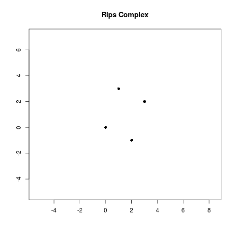

```r
S_RipsFilt <- ripsFiltration(S, maxdimension = 2,
                             maxscale = 4.5, dist = "euclidean")

class(S_RipsFilt) <- c(class(S_RipsFilt), "rips_filt")

plot(S_RipsFilt, animate = TRUE, fn_out = 'rips_example.gif',
     lout = 80, interval = 0.2)
```

### Non Euclidean Distance Example

Now we will compute a Rips filtration on
$$S$$
, but this time using the Manhattan distance or
$$\ell_1$$
norm. Recall, that for points,
$$\textbf{x}=(x_1,...,x_n)$$
and
$$\textbf{y}=(y_1,...,y_n)\in \mathbb{R}^n$$
, the Manhattan distance,
$$d_M(\textbf{x},\textbf{y})$$
is defined as:

$$d_M(\textbf{x},\textbf{y}):=\sum_{i=1}^{n}|x_i-y_i|.$$

In order to compute the Rips filtration on
$$S$$
for this metric, we need to create a distance matrix in R. We can do this using the following code.

```r
dist_matrix <- dist(S, method = "manhattan", diag = TRUE, upper = TRUE, p = 2)
```

Now when we use the ripsFiltration function, we will write dist_matrix as the first argument instead of
$$S$$
. Additionally, the fourth argument will change to dist = “arbitrary”.

```r
S_RipsFilt_Manhattan <- ripsFiltration(dist_matrix, maxdimension = 2,
                                       maxscale = 5, dist = "arbitrary")
```

This time when we compute the Rips complex with
$$r=\sqrt{13}$$
we get the following complex.

```r
S_RipsFilt_Manhattan <- ripsFiltration(dist_matrix, maxdimension = 2,
                                       maxscale = sqrt(13), dist = "arbitrary")

lim <- rep(c(-1, 3), 2)
plot(NULL, type = "n", xlim = lim[1:2], ylim = lim[3:4],
     main = "Rips Complex with Manhattan Distance for r = sqrt(13)",
     xlab = "", ylab = "")
for (idx in seq(along = S_RipsFilt_Manhattan[["cmplx"]])) {
  polygon(S[S_RipsFilt_Manhattan[["cmplx"]][[idx]], , drop = FALSE],
          col = "gray", border = NA, xlim = lim[1:2], ylim = lim[3:4])
}
for (idx in seq(along = S_RipsFilt_Manhattan[["cmplx"]])) {
  polygon(S[S_RipsFilt_Manhattan[["cmplx"]][[idx]], , drop = FALSE],
          col = NULL, xlim = lim[1:2], ylim = lim[3:4])
}
points(S, pch = 16)
dev.off()
```

[figure not shown]

Hence VR
$$(S, \sqrt{13})$$
with the Manhattan distance is a simplicial complex two edges, while with the Euclidean distance is a simplicial complex with two 2-simplices.

### Sightings of Bigfoot in Montana

Lastly, we will work through an example with real data! The Bigfoot Field Researchers Organization (BFRO) is the only scientific research organization studying the Bigfoot/Sasquatch mystery. They publically provide all Bigfoot sighting reports on their [website](http://www.bfro.net/). We will compute the Rips filtration for Bigfoot sightings in Montana with the hope of finding the dead zones where bigfoot has not been sighted in order to keep hikers safe from potential encounters.

```r
#Latitude coordinates of Bigfoot sightings in MT
latitude <- c(45.31278,46.05292,45.97540,47.62167,48.03278,47.70667,
              46.02962,47.66724,46.01833,46.97694,46.76389,45.12266,
              48.27011,46.76472,46.18694,48.36139,45.22417,47.60413,
              47.17833,45.28074,46.48392,47.57549,45.79220,45.61331,
              48.68000,46.30766,47.07444,47.04333,47.07954,46.83285,
              47.12808,46.59692,47.03222,47.06032,46.75889,46.96508,
              46.52520,45.66722,45.82285,45.02620,45.37050)

#Longitude coordinates of Bigfoot sightings in MT
longitude <- c(-109.64490,-112.57100,-112.45540,-115.39030,-105.86420,
               -104.19220,-113.11980,-108.68730,-110.33080,-113.83810,
               -110.77810,-111.56300,-115.64180,-111.88610,-113.69250,
               -113.12360,-111.12500,-113.75930,-111.97440,-109.55280,
               -111.26440,-114.2650,-111.36370,-110.78970,-113.82000,
               -113.14240,-111.96250,-112.70310,-112.56490,-112.70200,
               -111.90940,-110.62680,-114.09060,-114.07170,-114.08000,
               -114.07250,-113.59110,-110.80690,-114.01250,-106.83310,
               -112.97070)

#GPS coordinates of Bigfoot sightings in MT
bigfoot_sightingsMT <- cbind(latitude, longitude)
```

We can plot the data using the following code.

```r
plot(bigfoot_sightingsMT[,1],bigfoot_sightingsMT[,2], xlab = "Latitude",
     ylab = "Longitude", main = "GPS coordinates of Bigfoot sightings
     in Montana", pch=16)
```

[figure not shown]

Now let’s compute the filtration and visualize it with an animation.

```r
BigfootRipsFilt <- ripsFiltration(bigfoot_sightingsMT, maxdimension = 2,
                                  maxscale = 1.6, dist = "euclidean")

class(BigfootRipsFilt) <- c(class(BigfootRipsFilt), "rips_filt")

plot(BigfootRipsFilt, animate = TRUE, fn_out = 'bigfoot_ex.gif',
     lout = 80, interval = 0.2)
```

[figure not shown]

As we watch the animation, we see that even at low filtration values, there are lots of simplices near the GPS coordinates of Missoula, MT which corresponds to several bigfoot sightings in that area. Furthermore, at a filtration value of one, we see that the area surrounding Helena, MT is a deadzone. If we assume that Bigfoot does not travel radially outwards more than one latitude/longitude unit, then this suggests that hiking in Helena could help avoid Bigfoot encounters. Lastly, there have not been many sightings in Eastern MT, so perhaps Bigfoot does not roam around in that part of the state. We have not fully solved the Bigfoot mystery but the Rips complex and Rips filtration helps us get one step closer!

# References

{% bibliography –cited %}